# Statistical machine learning, Lab 7

# Local regression and Generalized Additive Models

## R packages we use in the lab

We are going to use `tidymodels` framework and `mgcv` package for GAM model fitting. An alternative implementation of GAM models is in the `gam` package, but since `mgcv` is considered more universal and can be used in `tidymodels` framework, we are not going to use the modeling command from `gam`.

## Datasets of the lab

We are going to use `Auto` dataset from `ISLR` package.

## Local regression

Local regression computes a predicted value at a given predictor value $x$ by choosing a certain fraction of observations from training data with predictor values closest to $x$ and fitting a low order polynomial regression model to those observations. The smoothness of the resulting predictor function is controlled by the fraction of points used. The command for fitting local regression curve is `loess()`, which is contained in the `stats` package. The most important parameters of the command are

- `formula`, which determines the response variable and up to 4 predictors
- `data` - data frame with training set information
- `span` - should be between 0 and 1 (default is 0.75), describes the proportion of observations used around gived $x$ value
- `degree` - degree of polynomials used. Default is 2, possible values are 0,1,2.
- `control=loess.control(surface="direct")` - forces actual local regression to be used. By default a certain number of local regression models are fitted and for new observations those models are used

### Exercise 1

Fit a local regression curve to `log(mpg)` as a function of `horsepower` by using quadratic regression and `span=0.1, 0.5, 0.8`

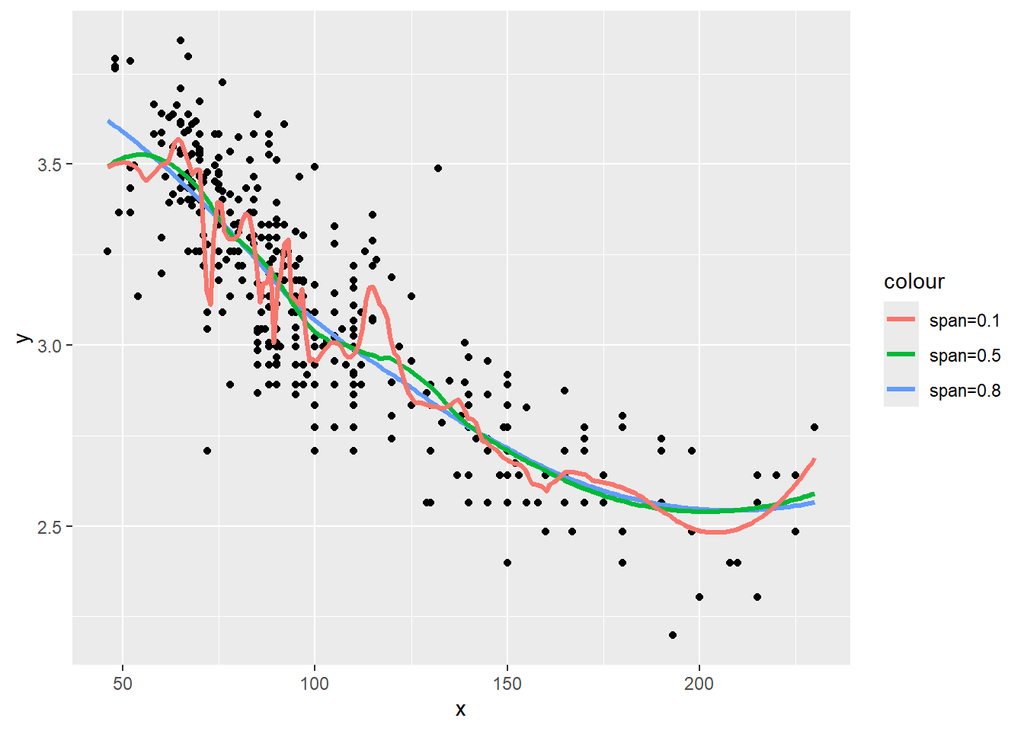

```r
y=log(ISLR::Auto$mpg)
x=ISLR::Auto$horsepower
newx=seq(min(x),max(x),length.out=201)
df1=data.frame(x=x,y=y)
lr_model1=loess(y~x,data=df1,span=0.8,control = loess.control(surface="direct"))
df2=data.frame(x=newx,.fitted=predict(lr_model1,data.frame(x=newx)))
plot=ggplot(df1,aes(x=x))+geom_point(aes(y=y))+geom_line(data=df2,aes(x=x,y=.fitted,color="span=0.8"),lwd=1.2)
lr_model2=loess(y~x,data=df1,span=0.5,control = loess.control(surface="direct"))
df2=data.frame(x=newx,.fitted=predict(lr_model2,data.frame(x=newx)))
plot=plot+geom_line(data=df2,aes(x=x,y=.fitted,color="span=0.5"),lwd=1.2)
lr_model3=loess(y~x,data=df1,span=0.1,control = loess.control(surface="direct"))
df2=data.frame(x=newx,.fitted=predict(lr_model3,data.frame(x=newx)))
plot=plot+geom_line(data=df2,aes(x=x,y=.fitted,color="span=0.1"),lwd=1.2)
plot
```

Since local regression is generally very time consuming when computing predictions (for each data point a new model has to be fitted), it is not very widely used as a component of high dimensional models. But if you want to try out GAM models with smooth terms computed by local regression, then it is possible to use `gam()` function from the package `gam`, which unfortunately can not be used with tidymodels framework. Therefore we do not consider it in this course.

## Fitting a generalized linear model with many predictors

Information about fitting GAM models with tidymodels framework:

- the GAM model is specified with `gen_additive_mod()` command. This command has parameters `mode` (classification or regression), `engine` (currently only mgcv), `select_features` (TRUE of FALSE, should automatic feature selection be performed with additional penalty terms) and `adjust_deg_free` (numeric, values larger than 1 increase smoothness of the result).
- one-variable smoothing terms can be indicated with a term `s(variable)` in the model formula
- the model can be fitted by several approaches:
  - model specification with fit command of the form: `model_spec |> fit(formula,data)`
  - by using workflows with formula indicated when model is added: the term `add_model()` in the workflow definition should be of the form `add_model(model_spec,formula=formula_with_smoothing_terms)`

Let us fit some GAM models for predicting `log(mpg)` by using several variables from the `Auto` data set.

### Exercise 2

Use `stats::step()` function to find the best linear regression model by starting from the model which uses all variables except `name`. Note that origin should be used as a factor variable. Check for bias with respect to all continuous variables used in the fit. Which ones may require nonlinear modelling?

*Solution* Fit a model and produce graphs:

```r
Auto_mod=ISLR::Auto|> mutate(logmpg=log(mpg),origin=factor(origin,levels=1:3))|>select(-mpg)
m3=stats::step(lm(logmpg ~ cylinders + displacement + horsepower +
    weight + origin + year+acceleration, data = Auto_mod))
```

```
## Start:  AIC=-1664.7
## logmpg ~ cylinders + displacement + horsepower + weight + origin +
##     year + acceleration
##
##                Df Sum of Sq    RSS     AIC
## - acceleration  1    0.0022 5.3606 -1666.5
## <none>                      5.3584 -1664.7
## - cylinders     1    0.0819 5.4403 -1660.8
## - displacement  1    0.1157 5.4741 -1658.3
## - horsepower    1    0.1345 5.4929 -1657.0
## - origin        2    0.3262 5.6845 -1645.5
## - weight        1    1.7737 7.1321 -1554.6
## - year          1    3.8047 9.1631 -1456.4
##
## Step:  AIC=-1666.54
## logmpg ~ cylinders + displacement + horsepower + weight + origin +
##     year
##
##                Df Sum of Sq    RSS     AIC
## <none>                      5.3606 -1666.5
## - cylinders     1    0.0808 5.4414 -1662.7
## - displacement  1    0.1201 5.4807 -1659.8
## - horsepower    1    0.1842 5.5448 -1655.3
## - origin        2    0.3256 5.6862 -1647.4
## - weight        1    2.3680 7.7286 -1525.1
## - year          1    3.8404 9.2010 -1456.8
```

```r
df3=augment(m3, new_data=Auto_mod)|>inner_join(Auto_mod) #to include all variables
```

[output not shown]

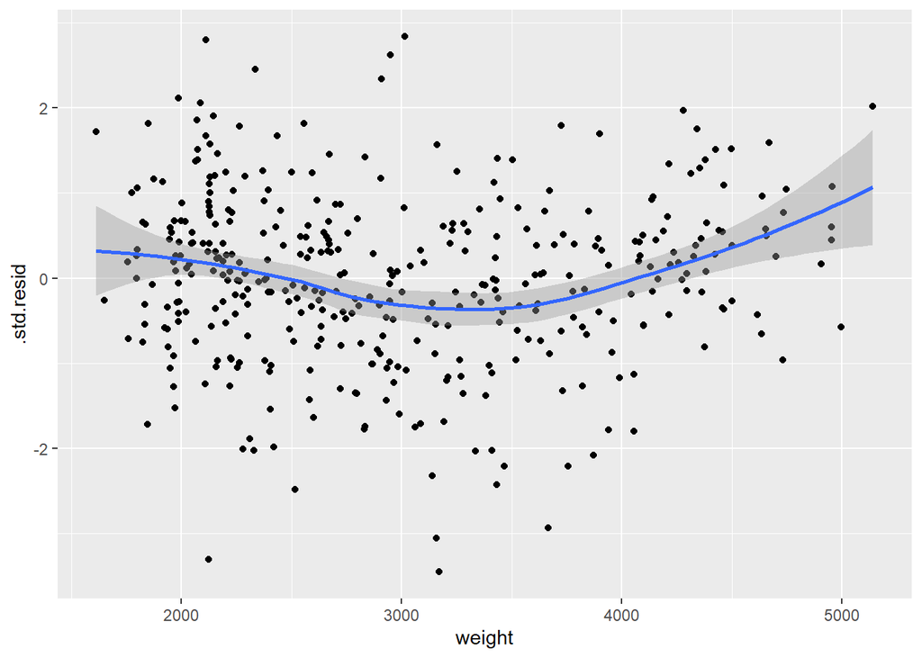

```r
ggplot(df3,aes(x=weight))+geom_point(aes(y=.std.resid))+geom_smooth(aes(y=.std.resid))
```

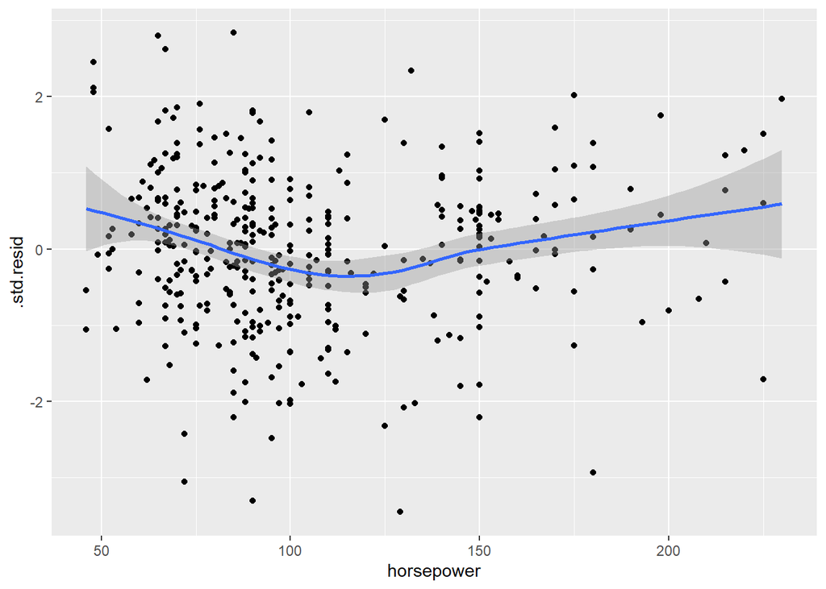

```r
ggplot(df3,aes(x=horsepower))+geom_point(aes(y=.std.resid))+geom_smooth(aes(y=.std.resid))
```

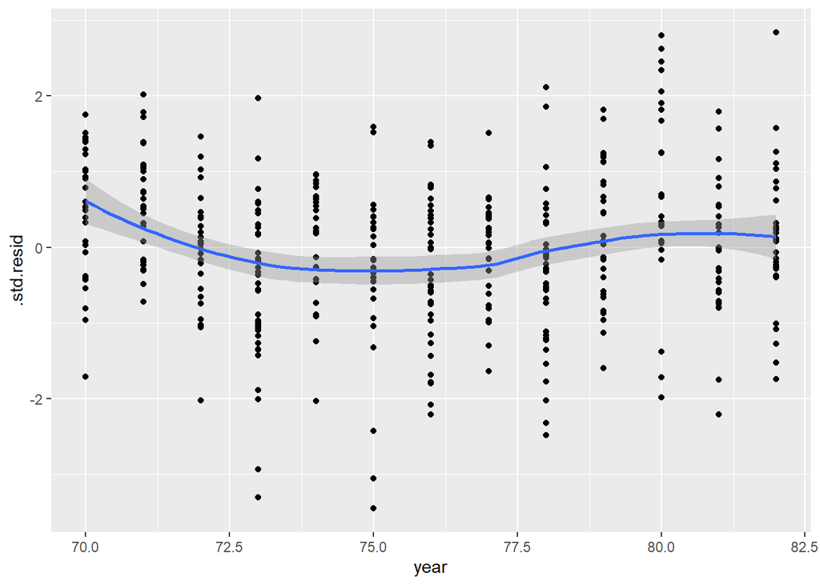

```r
ggplot(df3,aes(x=year))+geom_point(aes(y=.std.resid))+geom_smooth(aes(y=.std.resid))
```

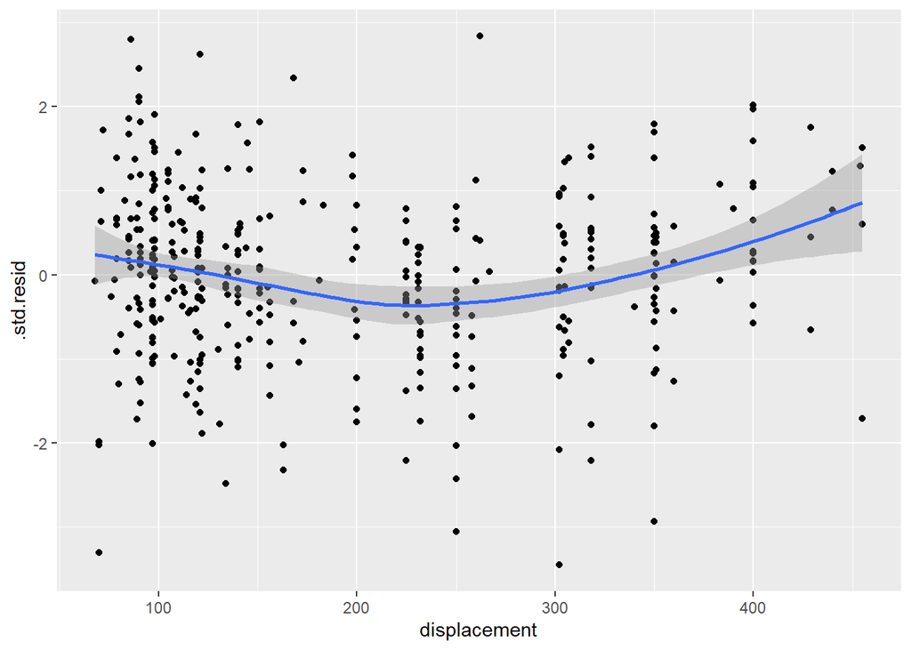

```r
ggplot(df3,aes(x=displacement))+geom_point(aes(y=.std.resid))+geom_smooth(aes(y=.std.resid))
```

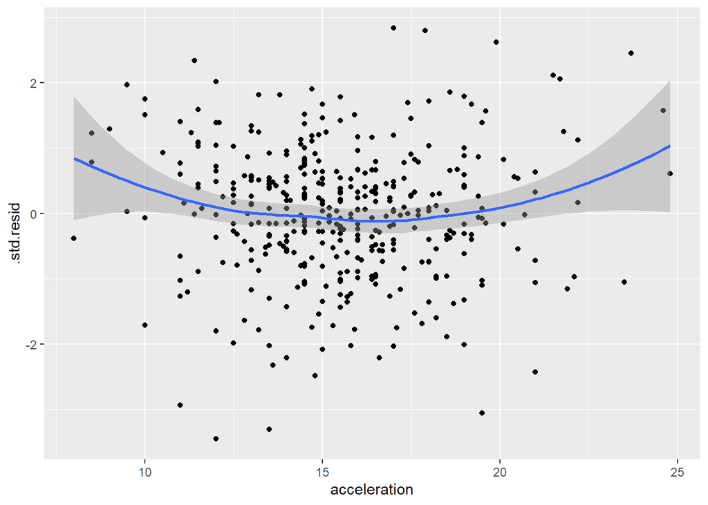

```r
ggplot(df3,aes(x=acceleration))+geom_point(aes(y=.std.resid))+geom_smooth(aes(y=.std.resid))
```

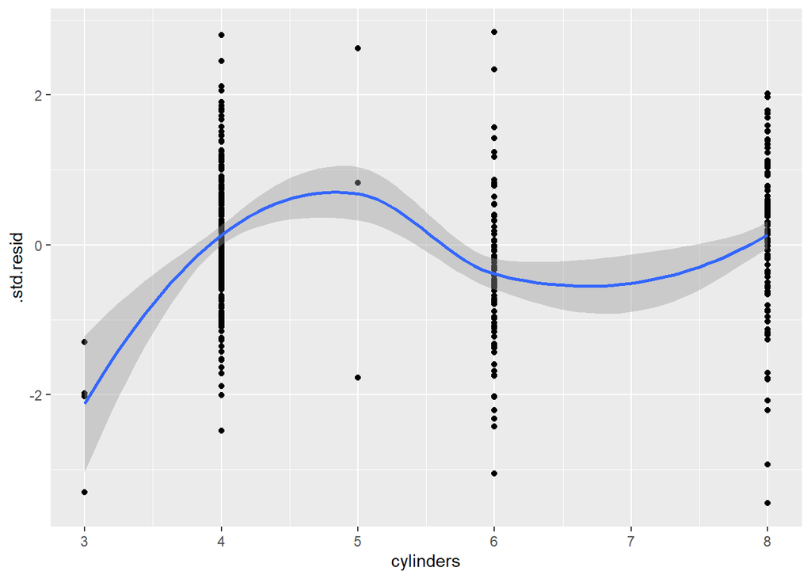

```r
ggplot(df3,aes(x=cylinders))+geom_point(aes(y=.std.resid))+geom_smooth(aes(y=.std.resid))
```

As we see, there are reasons to believe that it may be necessary to add nonlinear effects with respect to all continuous variables except, possibly, the variable `cylinders`. Although `cylinders` is used as continuous variable in the model, it has a small number of different values, some of which have a very small number of observations. It may be a good idea to add nonlinearities sequentially, since (especially in the case of strongly correlated variables like `horsepower` and `weight`) it may happen that after modelling nonlinearity with respect to some variables nonlinear effects with respect to some other variable disappear.

### Exercise 3

Fit a generalized additive model to the data by adding natural spline with 3 degrees of freedom to `year` variable and smoothing splines to displacement and weight terms (keeping other therms from the best model of the previous exercise). Compare by 5-fold cross-validation the results obtained with similar model where three-dimensional smoothing term in the form of tensor products (indicated with term `te()`) is added instead of individual smoothing and spline terms. Which model is better?

*Solution*

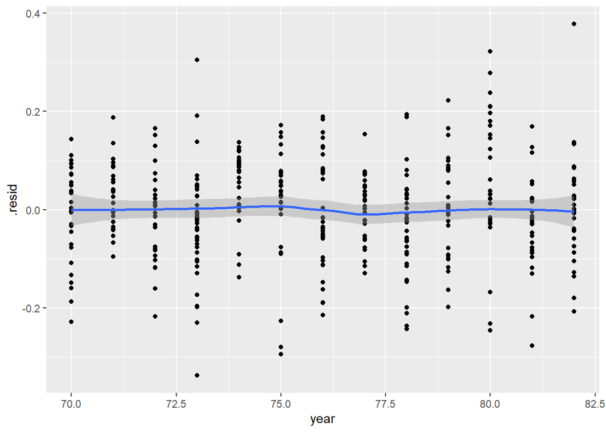

```r
m4=gen_additive_mod(mode="regression")|>fit(logmpg ~ cylinders + s(displacement) + horsepower + s(weight) + origin +
    splines::ns(year,df=3),data=Auto_mod)
#add predictions to data and compute correct residuals
df4=augment(m4, new_data=Auto_mod)
ggplot(df4,aes(x=year))+geom_point(aes(y=.resid))+geom_smooth(aes(y=.resid))
```

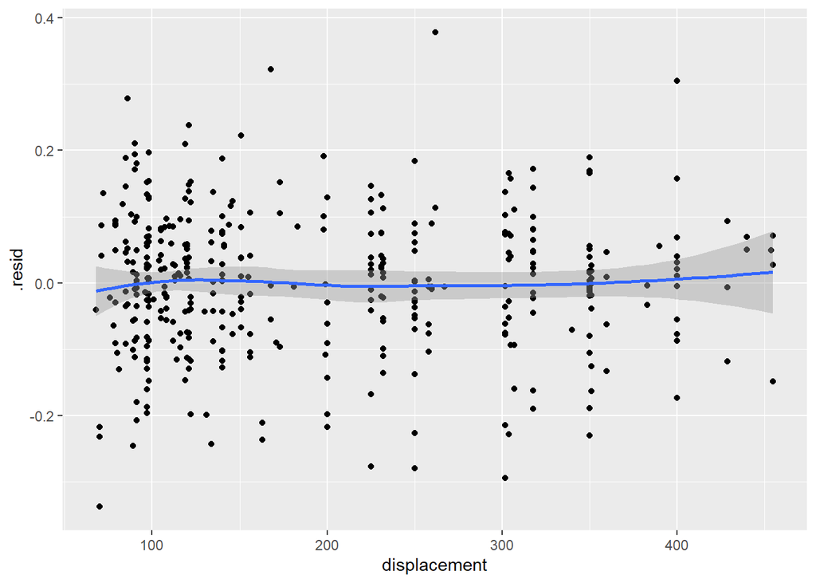

```r
ggplot(df4,aes(x=displacement))+geom_point(aes(y=.resid))+geom_smooth(aes(y=.resid))
```

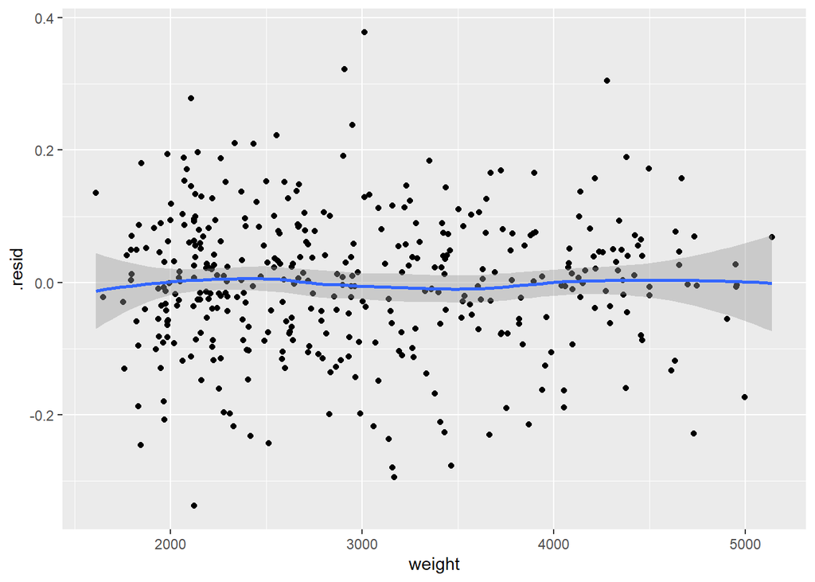

```r
ggplot(df4,aes(x=weight))+geom_point(aes(y=.resid))+geom_smooth(aes(y=.resid))
```

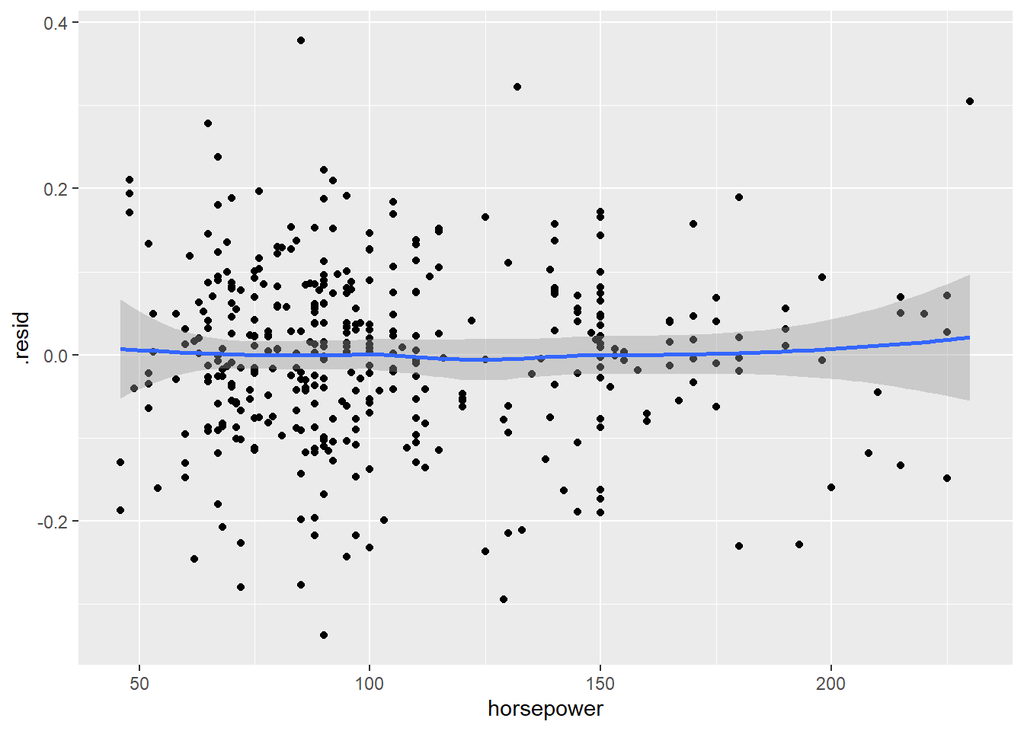

```r
ggplot(df4,aes(x=horsepower))+geom_point(aes(y=.resid))+geom_smooth(aes(y=.resid))
```

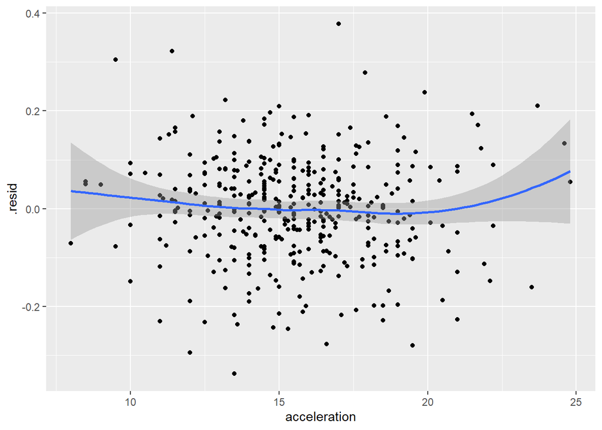

```r
ggplot(df4,aes(x=acceleration))+geom_point(aes(y=.resid))+geom_smooth(aes(y=.resid))
```

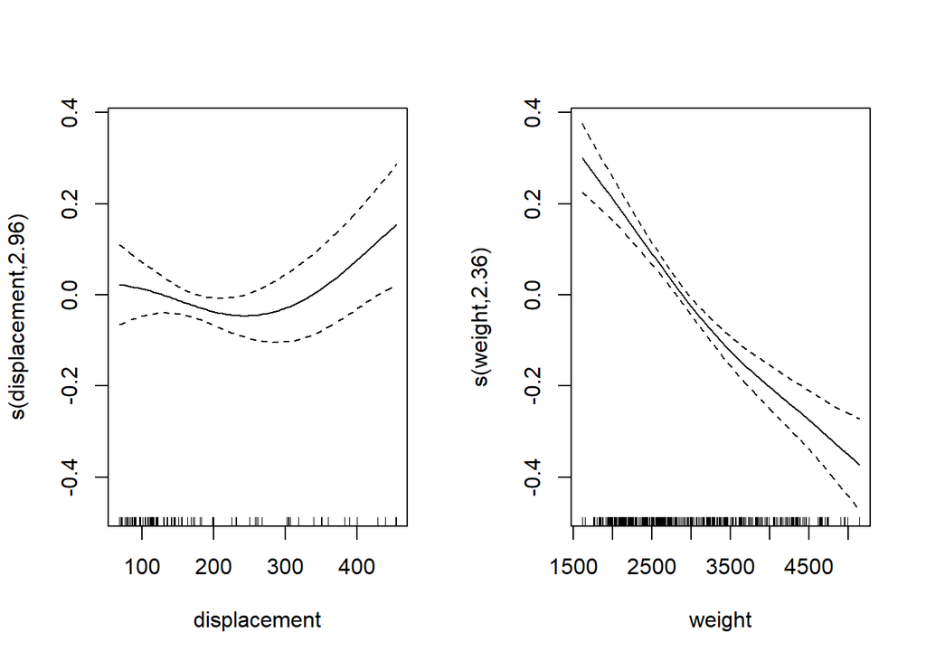

```r
plot(m4$fit,pages=1)
```

```r
tmp=data.frame(predict(m4,new_data = ISLR::Auto,type="raw",opts = list(type="terms")))
tibble(tmp)
```

| cylinders | horsepower | origin | splines..ns.year..df...3. | s.displacement. | s.weight. |
| --- | --- | --- | --- | --- | --- |
| 0.02777987 | -0.3441749 | 0.00000000 | 0.00000000 | -0.0249362451 | -0.1242836504 |
| 0.02777987 | -0.4368373 | 0.00000000 | 0.00000000 | 0.0125900138 | -0.1559067404 |
| 0.02777987 | -0.3971248 | 0.00000000 | 0.00000000 | -0.0171171219 | -0.1122206550 |
| 0.02777987 | -0.3971248 | 0.00000000 | 0.00000000 | -0.0268569758 | -0.1116796368 |
| 0.02777987 | -0.3706498 | 0.00000000 | 0.00000000 | -0.0280872929 | -0.1145563559 |
| 0.02777987 | -0.5242048 | 0.00000000 | 0.00000000 | 0.1169399700 | -0.2514248738 |
| 0.02777987 | -0.5824498 | 0.00000000 | 0.00000000 | 0.1525424454 | -0.2533137912 |
| 0.02777987 | -0.5692123 | 0.00000000 | 0.00000000 | 0.1326085403 | -0.2472237582 |
| 0.02777987 | -0.5956872 | 0.00000000 | 0.00000000 | 0.1539660229 | -0.2636970084 |
| 0.02777987 | -0.5030248 | 0.00000000 | 0.00000000 | 0.0623062494 | -0.1803020976 |

[output cut: 382 more lines]

```r
m5=gen_additive_mod(mode="regression")|>fit(logmpg ~ cylinders  + horsepower + te(weight,displacement,year) + origin ,data=Auto_mod)
#compare models by separate crossvalidation
set.seed(20241017)
cv=vfold_cv(Auto_mod,v=5)
wf4 = workflow()|>add_recipe(recipe(logmpg~.,data=Auto_mod))|>add_model(gen_additive_mod(mode="regression"),formula=logmpg ~  cylinders + s(displacement) + horsepower + s(weight) + origin +
    splines::ns(year,df=3))
res4=fit_resamples(wf4,cv,metrics = metric_set(rmse))
collect_metrics(res4)
```

| .metric | .estimator | mean | n | std_err | .config |
| --- | --- | --- | --- | --- | --- |
| rmse | standard | 0.1058921 | 5 | 0.007448758 | Preprocessor1_Model1 |

```r
wf5 = workflow()|>add_recipe(recipe(logmpg~.,data=Auto_mod))|>add_model(gen_additive_mod(mode="regression"),formula=logmpg ~ cylinders  + horsepower + te(weight,displacement,year) + origin)
res5=fit_resamples(wf5,cv,metrics = metric_set(rmse))
collect_metrics(res5)
```

| .metric | .estimator | mean | n | std_err | .config |
| --- | --- | --- | --- | --- | --- |
| rmse | standard | 0.1162849 | 5 | 0.01181329 | Preprocessor1_Model1 |

```r
#separate terms gave better average performance in the case of crossvalidation.
```

### Exercise 4

Instead of using tensor product splines, it is possible to fit multivariate non-linear smoothing terms with thin plate splines by including multiple variables in a single s() command and leaving the parameter `bs` to it’s default value (which is “tp”, thin plate splines). When using multivariate thin plate splines, the variables should be on a similar scale, so normalization is recommended. Compute cross-validation results of fitting similar model as previously with `te()` term without normalization and compare the results to the case, when the variables `year`,`weigth` and `displacement` are normalised.

*Solution*

```r
m6=gen_additive_mod(mode="regression")|>fit(logmpg ~ cylinders  + horsepower + s(weight,displacement,year) + origin ,Auto_mod)
wf6a=workflow()|>add_recipe(recipe(logmpg~.,data=Auto_mod))|>add_model(gen_additive_mod(mode="regression"),formula=logmpg ~ cylinders  + horsepower + s(weight,displacement,year) + origin)
res6a=fit_resamples(wf6a,cv,metrics = metric_set(rmse))
collect_metrics(res6a)
```

| .metric | .estimator | mean | n | std_err | .config |
| --- | --- | --- | --- | --- | --- |
| rmse | standard | 0.1089099 | 5 | 0.008119608 | Preprocessor1_Model1 |

```r
#separate terms gave better average performance in the case of crossvalidation.
wf6b=workflow()|>add_recipe(recipe(logmpg~.,data=Auto_mod)|>step_normalize(weight,displacement,year))|>add_model(gen_additive_mod(mode="regression"),formula=logmpg ~ cylinders  + horsepower + s(weight,displacement,year) + origin)
res6b=fit_resamples(wf6b,cv,metrics = metric_set(rmse))
collect_metrics(res6b)
```

| .metric | .estimator | mean | n | std_err | .config |
| --- | --- | --- | --- | --- | --- |
| rmse | standard | 0.1034483 | 5 | 0.007484159 | Preprocessor1_Model1 |